# MDS6212 Fintech Theory and Practice: Week 3 Assignment

**220041006 *Yihang Li***

**Data confidential requirements:**

- Do not share datasets with others
- Do not post datasets on the Web site
- Datasets can only be used to work on assignments of MDS6212, M.Sc. in Data Science, CUHK-Shenzhen.

**Datasets:**

- MDS6212 Week 3 Stock returns.xlsx
- MDS6212 Week 3 Online sales.xlsx

# Table of Contents

## Using the data set of stock returns, sort stocks into quintiles by size every quarter, hold stocks over the quarter, and calculate monthly portfolio returns

```python
Stock_returns = pd.read_excel('MDS6212 Week 3 Stock returns.xlsx', sheet_name='data')
Stock_returns.info()
```

```
<class 'pandas.core.frame.DataFrame'>
RangeIndex: 87432 entries, 0 to 87431
Data columns (total 19 columns):
 #   Column      Non-Null Count  Dtype
---  ------      --------------  -----
 0   stkcd       87432 non-null  int64
 1   stknme      87432 non-null  object
 2   conme       87432 non-null  object
 3   month       87432 non-null  object
 4   retrf       87432 non-null  float64
 5   mktrf       87432 non-null  float64
 6   smb         87432 non-null  float64
 7   hml         87432 non-null  float64
 8   umd         87432 non-null  float64
 9   size        87432 non-null  float64
 10  bm          87432 non-null  float64
 11  return12    87432 non-null  float64
 12  roa         87432 non-null  float64
 13  lev         87432 non-null  float64
 14  ppe         87432 non-null  float64
 15  intang      87432 non-null  float64
 16  numanalyst  87432 non-null  int64
 17  instown     87432 non-null  float64
 18  mv          87432 non-null  int64
dtypes: float64(13), int64(3), object(3)
memory usage: 12.7+ MB
```

```python
Stock_returns.head()
```

|  | stkcd | stknme | conme | month | retrf | mktrf | smb | hml | umd | size | bm | return12 | roa | lev | ppe | intang | numanalyst | instown | mv |
| --- | --- | --- | --- | --- | --- | --- | --- | --- | --- | --- | --- | --- | --- | --- | --- | --- | --- | --- | --- |
| 0 | 9 | 中国宝安 | 中国宝安集团股份有限公司 | 2013-07 | 9.0756 | 1.8833 | 5.1896 | -0.1922 | 6.1829 | 23.10871 | 0.438860 | 13.37412 | 0.007949 | 0.430605 | 0.086185 | 0.031575 | 0 | 6.4646 | 11874173952 |
| 1 | 9 | 中国宝安 | 中国宝安集团股份有限公司 | 2013-08 | -5.1363 | 4.5833 | 5.9407 | 0.0976 | -5.5041 | 23.10871 | 0.438860 | 13.37412 | 0.007949 | 0.430605 | 0.086185 | 0.031575 | 0 | 6.4646 | 11874173952 |
| 2 | 9 | 中国宝安 | 中国宝安集团股份有限公司 | 2013-09 | 3.5840 | 3.3833 | 0.5848 | 2.8554 | 8.8693 | 23.10871 | 0.438860 | 13.37412 | 0.007949 | 0.430605 | 0.086185 | 0.031575 | 0 | 6.4646 | 11874173952 |
| 3 | 9 | 中国宝安 | 中国宝安集团股份有限公司 | 2014-01 | -1.0932 | -3.6167 | 5.6921 | 1.1126 | 8.9357 | 23.28204 | 0.394303 | 46.59159 | 0.025973 | 0.432246 | 0.098660 | 0.029798 | 0 | 5.6741 | 11731143680 |
| 4 | 9 | 中国宝安 | 中国宝安集团股份有限公司 | 2014-02 | 19.0704 | 0.9833 | 3.8899 | 0.6902 | -1.8764 | 23.28204 | 0.394303 | 46.59159 | 0.025973 | 0.432246 | 0.098660 | 0.029798 | 0 | 5.6741 | 11731143680 |

```python
for key, group in Groupby_quarterly:
    print(key, ': the quintiles size are', group['size'].quantile(0.2),
          group['size'].quantile(0.4), group['size'].quantile(0.6),
          group['size'].quantile(0.8), group['size'].quantile(1),
          'respectivly.')
#sort stocks into quintiles by size every quarter
    First = group[group['size'] <= group['size'].quantile(0.2)].reset_index()
    Second = group[(group['size'] <= group['size'].quantile(0.4)) & (
        group['size'] > group['size'].quantile(0.2))].reset_index()
    Third = group[(group['size'] <= group['size'].quantile(0.6)) &
                  (group['size'] > group['size'].quantile(0.4))].reset_index()
    Fourth = group[(group['size'] <= group['size'].quantile(0.8)) & (
        group['size'] > group['size'].quantile(0.6))].reset_index()
    Fifth = group[(group['size'] <= group['size'].quantile(1)) &
                  (group['size'] > group['size'].quantile(0.8))].reset_index()

#hold stocks over the quarter, and calculate monthly portfolio returns weighted by mv (market value)
    First['weight'] = First['mv'] / First['mv'].sum()
    Second['weight'] = Second['mv'] / Second['mv'].sum()
    Third['weight'] = Third['mv'] / Third['mv'].sum()
    Fourth['weight'] = Fourth['mv'] / Fourth['mv'].sum()
    Fifth['weight'] = Fifth['mv'] / Fifth['mv'].sum()

    Portfolio_First = First['weight'].dot(First['retrf'])
    Portfolio_Second = Second['weight'].dot(Second['retrf'])
    Portfolio_Third = Third['weight'].dot(Third['retrf'])
    Portfolio_Fourth = Fourth['weight'].dot(Fourth['retrf'])
    Portfolio_Fifth = Fifth['weight'].dot(Fifth['retrf'])

    print("#" * 20, key, "#" * 20)
    print(
        "After sort stocks into quintiles by size every quarter", '\n',
        "the monthly portfolio returns weighted by market value of: Fisrt quintile is", Portfolio_First,
        '\n', "the monthly portfolio returns weighted by market value of: Second quintile is",
        Portfolio_Second, '\n',
        "the monthly portfolio returns weighted by market value of: Third quintile is", Portfolio_Third,
        '\n', "the monthly portfolio returns weighted by market value of: Fourth quintile is",
        Portfolio_Fourth, '\n',
        "the monthly portfolio returns weighted by market value of: Fifth quintile is", Portfolio_Fifth)
    print("#" * 60)
```

```
2012Q2 : the quintiles size are 21.32591 21.6943 22.04578 22.66286 28.08662 respectivly.
#################### 2012Q2 ####################
After sort stocks into quintiles by size every quarter
 the monthly portfolio returns weighted by market value of: Fisrt quintile is -1.0948317304800814
 the monthly portfolio returns weighted by market value of: Second quintile is 0.6517450687480695
 the monthly portfolio returns weighted by market value of: Third quintile is 1.2373100473703458
 the monthly portfolio returns weighted by market value of: Fourth quintile is 0.2188063469501672
 the monthly portfolio returns weighted by market value of: Fifth quintile is -1.2361876312917217
############################################################
2012Q3 : the quintiles size are 21.271824000000002 21.64703 22.01655 22.623397999999998 28.08148 respectivly.
#################### 2012Q3 ####################
After sort stocks into quintiles by size every quarter
 the monthly portfolio returns weighted by market value of: Fisrt quintile is -1.487507803103864
 the monthly portfolio returns weighted by market value of: Second quintile is -2.013719440924638
 the monthly portfolio returns weighted by market value of: Third quintile is -2.7894615483089336
 the monthly portfolio returns weighted by market value of: Fourth quintile is -2.632842591560488
 the monthly portfolio returns weighted by market value of: Fifth quintile is -1.8212085074617592
############################################################
2012Q4 : the quintiles size are 21.24419 21.664829999999995 22.064930000000004 22.67425 28.01315 respectivly.
#################### 2012Q4 ####################
After sort stocks into quintiles by size every quarter
 the monthly portfolio returns weighted by market value of: Fisrt quintile is 1.4893154465079714
 the monthly portfolio returns weighted by market value of: Second quintile is 0.6532805354728961
 the monthly portfolio returns weighted by market value of: Third quintile is 0.6223574009036166
 the monthly portfolio returns weighted by market value of: Fourth quintile is 0.41295860358567427
 the monthly portfolio returns weighted by market value of: Fifth quintile is 1.8614957532860972
############################################################
2013Q1 : the quintiles size are 21.202088000000003 21.518680000000003 21.93481 22.572513999999998 27.98286 respectivly.
#################### 2013Q1 ####################
After sort stocks into quintiles by size every quarter
 the monthly portfolio returns weighted by market value of: Fisrt quintile is 3.0343711264011977
 the monthly portfolio returns weighted by market value of: Second quintile is 3.115383675029271
 the monthly portfolio returns weighted by market value of: Third quintile is 3.159069500584303
 the monthly portfolio returns weighted by market value of: Fourth quintile is 2.3962386309968426
 the monthly portfolio returns weighted by market value of: Fifth quintile is 0.12670551028803512
############################################################
2013Q2 : the quintiles size are 21.16861 21.52147 21.92484 22.54107 28.01204 respectivly.
#################### 2013Q2 ####################
After sort stocks into quintiles by size every quarter
 the monthly portfolio returns weighted by market value of: Fisrt quintile is -0.4913801682759582
```

[output cut: 224 more lines]

```
 the monthly portfolio returns weighted by market value of: Fisrt quintile is -0.362091169380437
 the monthly portfolio returns weighted by market value of: Second quintile is -0.7508627434592454
 the monthly portfolio returns weighted by market value of: Third quintile is -0.48505827969270565
 the monthly portfolio returns weighted by market value of: Fourth quintile is -0.47829928267772776
 the monthly portfolio returns weighted by market value of: Fifth quintile is 0.6921527597038504
############################################################
2019Q4 : the quintiles size are 21.693058 22.06772 22.452406 23.050434 26.98228 respectivly.
#################### 2019Q4 ####################
After sort stocks into quintiles by size every quarter
 the monthly portfolio returns weighted by market value of: Fisrt quintile is 2.3407029844251723
 the monthly portfolio returns weighted by market value of: Second quintile is 1.8878460138231747
 the monthly portfolio returns weighted by market value of: Third quintile is 1.7166625353674596
 the monthly portfolio returns weighted by market value of: Fourth quintile is 2.0047714577808913
 the monthly portfolio returns weighted by market value of: Fifth quintile is 2.544554705775772
############################################################
```

## Using the data set of stock returns, sort stocks into quintiles by institutional ownership every quarter, hold stocks over the quarter, and calculate monthly portfolio returns

```python
for key, group in Groupby_quarterly:
    print(key, ': the quintiles instown are', group['instown'].quantile(0.2),
          group['instown'].quantile(0.4), group['instown'].quantile(0.6),
          group['instown'].quantile(0.8), group['instown'].quantile(1), 'respectivly.')

#sort stocks into quintiles by institutional ownership every quarter
    First = group[group['instown'] <= group['instown'].quantile(0.2)].reset_index()
    Second = group[(group['instown'] <= group['instown'].quantile(0.4)) & (
        group['instown'] > group['instown'].quantile(0.2))].reset_index()
    Third = group[(group['instown'] <= group['instown'].quantile(0.6)) &
                  (group['instown'] > group['instown'].quantile(0.4))].reset_index()
    Fourth = group[(group['instown'] <= group['instown'].quantile(0.8)) & (
        group['instown'] > group['instown'].quantile(0.6))].reset_index()
    Fifth = group[(group['instown'] <= group['instown'].quantile(1)) &
                  (group['instown'] > group['instown'].quantile(0.8))].reset_index()

#hold stocks over the quarter, and calculate monthly portfolio returns weighted by market value
    First['weight'] = First['mv'] / First['mv'].sum()
    Second['weight'] = Second['mv'] / Second['mv'].sum()
    Third['weight'] = Third['mv'] / Third['mv'].sum()
    Fourth['weight'] = Fourth['mv'] / Fourth['mv'].sum()
    Fifth['weight'] = Fifth['mv'] / Fifth['mv'].sum()

    Portfolio_First = First['weight'].dot(First['retrf'])
    Portfolio_Second = Second['weight'].dot(Second['retrf'])
    Portfolio_Third = Third['weight'].dot(Third['retrf'])
    Portfolio_Fourth = Fourth['weight'].dot(Fourth['retrf'])
    Portfolio_Fifth = Fifth['weight'].dot(Fifth['retrf'])

    print("#" * 20, key, "#" * 20)
    print(
        "After sort stocks into quintiles by size every quarter", '\n',
        "the monthly portfolio returns weighted by market value of: Fisrt quintile is", Portfolio_First,
        '\n', "the monthly portfolio returns weighted by market value of: Second quintile is",
        Portfolio_Second, '\n',
        "the monthly portfolio returns weighted by market value of: Third quintile is", Portfolio_Third,
        '\n', "the monthly portfolio returns weighted by market value of: Fourth quintile is",
        Portfolio_Fourth, '\n',
        "the monthly portfolio returns weighted by market value of: Fifth quintile is", Portfolio_Fifth)
    print("#" * 60)
```

```
2012Q2 : the quintiles instown are 0.804 3.4267 7.4483 16.2503 59.0109 respectivly.
#################### 2012Q2 ####################
After sort stocks into quintiles by size every quarter
 the monthly portfolio returns weighted by market value of: Fisrt quintile is -1.7724779451858177
 the monthly portfolio returns weighted by market value of: Second quintile is -2.759669084525224
 the monthly portfolio returns weighted by market value of: Third quintile is 1.1906890107162706
 the monthly portfolio returns weighted by market value of: Fourth quintile is 0.8069373046159043
 the monthly portfolio returns weighted by market value of: Fifth quintile is 1.2205498572591813
############################################################
2012Q3 : the quintiles instown are 0.5764999999999996 3.9008000000000003 9.4383 20.47526 74.9974 respectivly.
#################### 2012Q3 ####################
After sort stocks into quintiles by size every quarter
 the monthly portfolio returns weighted by market value of: Fisrt quintile is -0.8122206841219672
 the monthly portfolio returns weighted by market value of: Second quintile is -2.0652458554446254
 the monthly portfolio returns weighted by market value of: Third quintile is -3.9944366779894263
 the monthly portfolio returns weighted by market value of: Fourth quintile is -4.603409334777611
 the monthly portfolio returns weighted by market value of: Fifth quintile is -1.0113690234746031
############################################################
2012Q4 : the quintiles instown are 0.56575 2.7402999999999995 6.6695 16.3731 49.5527 respectivly.
#################### 2012Q4 ####################
After sort stocks into quintiles by size every quarter
 the monthly portfolio returns weighted by market value of: Fisrt quintile is 0.8137454834291209
 the monthly portfolio returns weighted by market value of: Second quintile is 3.844221534087262
 the monthly portfolio returns weighted by market value of: Third quintile is 1.172561359748241
 the monthly portfolio returns weighted by market value of: Fourth quintile is 2.095099180219401
 the monthly portfolio returns weighted by market value of: Fifth quintile is 1.1872345394503194
############################################################
2013Q1 : the quintiles instown are 0.4615200000000001 2.9089 8.589159999999996 21.896480000000018 75.4604 respectivly.
#################### 2013Q1 ####################
After sort stocks into quintiles by size every quarter
 the monthly portfolio returns weighted by market value of: Fisrt quintile is -1.200877312109641
 the monthly portfolio returns weighted by market value of: Second quintile is 2.496645273479349
 the monthly portfolio returns weighted by market value of: Third quintile is -0.9275530750024135
 the monthly portfolio returns weighted by market value of: Fourth quintile is 0.5403747909623838
 the monthly portfolio returns weighted by market value of: Fifth quintile is 5.06699361227672
############################################################
2013Q2 : the quintiles instown are 0.3728 2.0649 5.6366 14.19265 49.5507 respectivly.
#################### 2013Q2 ####################
After sort stocks into quintiles by size every quarter
 the monthly portfolio returns weighted by market value of: Fisrt quintile is -3.8074007264618994
```

[output cut: 224 more lines]

```
 the monthly portfolio returns weighted by market value of: Fisrt quintile is -1.8364409959031398
 the monthly portfolio returns weighted by market value of: Second quintile is -1.5103286862884784
 the monthly portfolio returns weighted by market value of: Third quintile is -1.2322175591218383
 the monthly portfolio returns weighted by market value of: Fourth quintile is 0.3651309554096154
 the monthly portfolio returns weighted by market value of: Fifth quintile is 1.9850569655887749
############################################################
2019Q4 : the quintiles instown are 0.06462 0.5446599999999998 1.7190600000000003 5.844759999999998 82.79221 respectivly.
#################### 2019Q4 ####################
After sort stocks into quintiles by size every quarter
 the monthly portfolio returns weighted by market value of: Fisrt quintile is 1.3766459971854685
 the monthly portfolio returns weighted by market value of: Second quintile is 1.6462097828564954
 the monthly portfolio returns weighted by market value of: Third quintile is 1.5566495313627415
 the monthly portfolio returns weighted by market value of: Fourth quintile is 3.0155727139022193
 the monthly portfolio returns weighted by market value of: Fifth quintile is 2.7870142539592955
############################################################
```

## Using the data set of stock returns, perform panel regression, and regress stock returns on firm characteristics such as size, book-to-market ratio, return12, roa, leverage, ppe, intang, number of analysts, institutional ownership, controlling for or not for firm and year-month fixed effects. Cluster standard errors by firm and year-month (double clustering)

[Reference](https://bashtage.github.io/linearmodels/panel/examples/examples.html)

```python
Stock_returns.head(1)
```

|  | stkcd | stknme | conme | month | retrf | mktrf | smb | hml | umd | size | bm | return12 | roa | lev | ppe | intang | numanalyst | instown | mv |
| --- | --- | --- | --- | --- | --- | --- | --- | --- | --- | --- | --- | --- | --- | --- | --- | --- | --- | --- | --- |
| 0 | 9 | 中国宝安 | 中国宝安集团股份有限公司 | 2013-07-01 | 9.0756 | 1.8833 | 5.1896 | -0.1922 | 6.1829 | 23.10871 | 0.43886 | 13.37412 | 0.007949 | 0.430605 | 0.086185 | 0.031575 | 0 | 6.4646 | 11874173952 |

### Data Formats for Panel Data Analysis

```
Here's one method to express data:
    MultiIndex DataFrames where the outer index is the entity and the inner is the time index. This requires using pandas.
```

```python
month = pd.Categorical(Stock_returns.month)
data = Stock_returns.set_index(['conme', 'month'])
data['month'] = month
data.head()
```

| conme | month | stkcd | stknme | retrf | mktrf | smb | hml | umd | size | bm | return12 | roa | lev | ppe | intang | numanalyst | instown | mv | month |
| --- | --- | --- | --- | --- | --- | --- | --- | --- | --- | --- | --- | --- | --- | --- | --- | --- | --- | --- | --- |
| 中国宝安集团股份有限公司 | 2013-07-01 | 9 | 中国宝安 | 9.0756 | 1.8833 | 5.1896 | -0.1922 | 6.1829 | 23.10871 | 0.438860 | 13.37412 | 0.007949 | 0.430605 | 0.086185 | 0.031575 | 0 | 6.4646 | 11874173952 | 2013-07-01 |
|  | 2013-08-01 | 9 | 中国宝安 | -5.1363 | 4.5833 | 5.9407 | 0.0976 | -5.5041 | 23.10871 | 0.438860 | 13.37412 | 0.007949 | 0.430605 | 0.086185 | 0.031575 | 0 | 6.4646 | 11874173952 | 2013-08-01 |
|  | 2013-09-01 | 9 | 中国宝安 | 3.5840 | 3.3833 | 0.5848 | 2.8554 | 8.8693 | 23.10871 | 0.438860 | 13.37412 | 0.007949 | 0.430605 | 0.086185 | 0.031575 | 0 | 6.4646 | 11874173952 | 2013-09-01 |
|  | 2014-01-01 | 9 | 中国宝安 | -1.0932 | -3.6167 | 5.6921 | 1.1126 | 8.9357 | 23.28204 | 0.394303 | 46.59159 | 0.025973 | 0.432246 | 0.098660 | 0.029798 | 0 | 5.6741 | 11731143680 | 2014-01-01 |
|  | 2014-02-01 | 9 | 中国宝安 | 19.0704 | 0.9833 | 3.8899 | 0.6902 | -1.8764 | 23.28204 | 0.394303 | 46.59159 | 0.025973 | 0.432246 | 0.098660 | 0.029798 | 0 | 5.6741 | 11731143680 | 2014-02-01 |

### year-month fixed effects

```python
data.columns
```

```
Index(['stkcd', 'stknme', 'retrf', 'mktrf', 'smb', 'hml', 'umd', 'size', 'bm',
       'return12', 'roa', 'lev', 'ppe', 'intang', 'numanalyst', 'instown',
       'mv', 'month'],
      dtype='object')
```

```python
exog_vars = ['size', 'bm',
       'return12', 'roa', 'lev', 'ppe', 'intang', 'numanalyst', 'instown']
exog = sm.add_constant(data[exog_vars])
mod = PanelOLS(data.retrf, exog, time_effects=True)
te_res = mod.fit()
te_res
```

PanelOLS Estimation Summary

| Dep. Variable: | retrf | R-squared: | 0.0017 |
| --- | --- | --- | --- |
| Estimator: | PanelOLS | R-squared (Between): | -0.0512 |
| No. Observations: | 87432 | R-squared (Within): | 0.0037 |
| Date: | Mon, Oct 19 2020 | R-squared (Overall): | 0.0028 |
| Time: | 20:00:56 | Log-likelihood | -3.29e+05 |
| Cov. Estimator: | Unadjusted |  |  |
|  |  | F-statistic: | 16.498 |
| Entities: | 2035 | P-value | 0.0000 |
| Avg Obs: | 42.964 | Distribution: | F(9,87330) |
| Min Obs: | 3.0000 |  |  |
| Max Obs: | 93.000 | F-statistic (robust): | 16.498 |
|  |  | P-value | 0.0000 |
| Time periods: | 93 | Distribution: | F(9,87330) |
| Avg Obs: | 940.13 |  |  |
| Min Obs: | 388.00 |  |  |
| Max Obs: | 1825.0 |  |  |

Parameter Estimates

|  | Parameter | Std. Err. | T-stat | P-value | Lower CI | Upper CI |
| --- | --- | --- | --- | --- | --- | --- |
| const | 9.0774 | 1.1444 | 7.9317 | 0.0000 | 6.8343 | 11.321 |
| size | -0.3764 | 0.0522 | -7.2090 | 0.0000 | -0.4788 | -0.2741 |
| bm | 0.1787 | 0.1162 | 1.5372 | 0.1242 | -0.0491 | 0.4065 |
| return12 | -0.0034 | 0.0008 | -4.4281 | 0.0000 | -0.0050 | -0.0019 |
| roa | 7.5939 | 1.4735 | 5.1536 | 0.0000 | 4.7058 | 10.482 |
| lev | -0.7737 | 0.2386 | -3.2422 | 0.0012 | -1.2414 | -0.3060 |
| ppe | 0.2224 | 0.2803 | 0.7935 | 0.4275 | -0.3270 | 0.7718 |
| intang | -0.2063 | 0.8393 | -0.2458 | 0.8059 | -1.8513 | 1.4388 |
| numanalyst | 0.0058 | 0.0046 | 1.2618 | 0.2070 | -0.0032 | 0.0149 |
| instown | 0.0203 | 0.0041 | 4.9306 | 0.0000 | 0.0122 | 0.0284 |

F-test for Poolability: 658.29  
P-value: 0.0000  
Distribution: F(92,87330)  
Included effects: Time  
id: 0x7fbc047684c0

### firm fixed effects

```python
exog_vars = ['size', 'bm',
       'return12', 'roa', 'lev', 'ppe', 'intang', 'numanalyst', 'instown']
exog = sm.add_constant(data[exog_vars])
mod = PanelOLS(data.retrf, exog, entity_effects=True)
fe_res = mod.fit()
fe_res
```

PanelOLS Estimation Summary

| Dep. Variable: | retrf | R-squared: | 0.0151 |
| --- | --- | --- | --- |
| Estimator: | PanelOLS | R-squared (Between): | -2.0078 |
| No. Observations: | 87432 | R-squared (Within): | 0.0151 |
| Date: | Mon, Oct 19 2020 | R-squared (Overall): | -0.0424 |
| Time: | 20:00:58 | Log-likelihood | -3.509e+05 |
| Cov. Estimator: | Unadjusted |  |  |
|  |  | F-statistic: | 145.82 |
| Entities: | 2035 | P-value | 0.0000 |
| Avg Obs: | 42.964 | Distribution: | F(9,85388) |
| Min Obs: | 3.0000 |  |  |
| Max Obs: | 93.000 | F-statistic (robust): | 145.82 |
|  |  | P-value | 0.0000 |
| Time periods: | 93 | Distribution: | F(9,85388) |
| Avg Obs: | 940.13 |  |  |
| Min Obs: | 388.00 |  |  |
| Max Obs: | 1825.0 |  |  |

Parameter Estimates

|  | Parameter | Std. Err. | T-stat | P-value | Lower CI | Upper CI |
| --- | --- | --- | --- | --- | --- | --- |
| const | 74.327 | 3.0474 | 24.391 | 0.0000 | 68.355 | 80.300 |
| size | -3.3042 | 0.1313 | -25.159 | 0.0000 | -3.5616 | -3.0467 |
| bm | -2.1903 | 0.3602 | -6.0804 | 0.0000 | -2.8964 | -1.4843 |
| return12 | -0.0127 | 0.0009 | -14.698 | 0.0000 | -0.0144 | -0.0110 |
| roa | 17.543 | 2.1518 | 8.1530 | 0.0000 | 13.326 | 21.761 |
| lev | 6.1501 | 0.5991 | 10.266 | 0.0000 | 4.9760 | 7.3243 |
| ppe | 2.0866 | 0.9792 | 2.1310 | 0.0331 | 0.1674 | 4.0058 |
| intang | 7.0475 | 2.3046 | 3.0580 | 0.0022 | 2.5305 | 11.565 |
| numanalyst | -0.0549 | 0.0084 | -6.5076 | 0.0000 | -0.0714 | -0.0383 |
| instown | 0.0480 | 0.0078 | 6.1638 | 0.0000 | 0.0327 | 0.0633 |

F-test for Poolability: 1.1154  
P-value: 0.0002  
Distribution: F(2034,85388)  
Included effects: Entity  
id: 0x7fbc04ffe250

### firm and year-month fixed effects

```python
exog_vars = ['size', 'bm',
       'return12', 'roa', 'lev', 'ppe', 'intang', 'numanalyst', 'instown']
exog = sm.add_constant(data[exog_vars])
mod = PanelOLS(data.retrf, exog, entity_effects=True, time_effects=True)
fe_te_res = mod.fit()
fe_te_res
```

PanelOLS Estimation Summary

| Dep. Variable: | retrf | R-squared: | 0.0123 |
| --- | --- | --- | --- |
| Estimator: | PanelOLS | R-squared (Between): | -1.8962 |
| No. Observations: | 87432 | R-squared (Within): | 0.0111 |
| Date: | Mon, Oct 19 2020 | R-squared (Overall): | -0.0440 |
| Time: | 20:01:03 | Log-likelihood | -3.277e+05 |
| Cov. Estimator: | Unadjusted |  |  |
|  |  | F-statistic: | 117.96 |
| Entities: | 2035 | P-value | 0.0000 |
| Avg Obs: | 42.964 | Distribution: | F(9,85296) |
| Min Obs: | 3.0000 |  |  |
| Max Obs: | 93.000 | F-statistic (robust): | 117.96 |
|  |  | P-value | 0.0000 |
| Time periods: | 93 | Distribution: | F(9,85296) |
| Avg Obs: | 940.13 |  |  |
| Min Obs: | 388.00 |  |  |
| Max Obs: | 1825.0 |  |  |

Parameter Estimates

|  | Parameter | Std. Err. | T-stat | P-value | Lower CI | Upper CI |
| --- | --- | --- | --- | --- | --- | --- |
| const | 83.922 | 3.4666 | 24.209 | 0.0000 | 77.128 | 90.717 |
| size | -3.6951 | 0.1517 | -24.366 | 0.0000 | -3.9924 | -3.3979 |
| bm | 0.4304 | 0.3158 | 1.3628 | 0.1729 | -0.1886 | 1.0494 |
| return12 | -0.0048 | 0.0009 | -5.5827 | 0.0000 | -0.0065 | -0.0031 |
| roa | 7.2873 | 1.6798 | 4.3381 | 0.0000 | 3.9948 | 10.580 |
| lev | -1.0791 | 0.5365 | -2.0114 | 0.0443 | -2.1305 | -0.0276 |
| ppe | -0.1872 | 0.7589 | -0.2467 | 0.8052 | -1.6746 | 1.3002 |
| intang | 3.0122 | 1.7734 | 1.6986 | 0.0894 | -0.4635 | 6.4880 |
| numanalyst | 0.0003 | 0.0070 | 0.0399 | 0.9682 | -0.0135 | 0.0141 |
| instown | 0.0199 | 0.0063 | 3.1561 | 0.0016 | 0.0075 | 0.0323 |

F-test for Poolability: 29.828  
P-value: 0.0000  
Distribution: F(2126,85296)  
Included effects: Entity, Time  
id: 0x7fbc05298c40

### Comparing models

```python
from linearmodels.panel import compare
compare({'TE':te_res, 'FE': fe_res, 'FE_TE':fe_te_res})
```

Model Comparison

|  | TE | FE | FE_TE |
| --- | --- | --- | --- |
| Dep. Variable | retrf | retrf | retrf |
| Estimator | PanelOLS | PanelOLS | PanelOLS |
| No. Observations | 87432 | 87432 | 87432 |
| Cov. Est. | Unadjusted | Unadjusted | Unadjusted |
| R-squared | 0.0017 | 0.0151 | 0.0123 |
| R-Squared (Within) | 0.0037 | 0.0151 | 0.0111 |
| R-Squared (Between) | -0.0512 | -2.0078 | -1.8962 |
| R-Squared (Overall) | 0.0028 | -0.0424 | -0.0440 |
| F-statistic | 16.498 | 145.82 | 117.96 |
| P-value (F-stat) | 0.0000 | 0.0000 | 0.0000 |
| ===================== | ============ | ============ | ============ |
| const | 9.0774 | 74.327 | 83.922 |
|  | (7.9317) | (24.391) | (24.209) |
| size | -0.3764 | -3.3042 | -3.6951 |
|  | (-7.2090) | (-25.159) | (-24.366) |
| bm | 0.1787 | -2.1903 | 0.4304 |
|  | (1.5372) | (-6.0804) | (1.3628) |
| return12 | -0.0034 | -0.0127 | -0.0048 |
|  | (-4.4281) | (-14.698) | (-5.5827) |
| roa | 7.5939 | 17.543 | 7.2873 |
|  | (5.1536) | (8.1530) | (4.3381) |
| lev | -0.7737 | 6.1501 | -1.0791 |
|  | (-3.2422) | (10.266) | (-2.0114) |
| ppe | 0.2224 | 2.0866 | -0.1872 |
|  | (0.7935) | (2.1310) | (-0.2467) |
| intang | -0.2063 | 7.0475 | 3.0122 |
|  | (-0.2458) | (3.0580) | (1.6986) |
| numanalyst | 0.0058 | -0.0549 | 0.0003 |
|  | (1.2618) | (-6.5076) | (0.0399) |
| instown | 0.0203 | 0.0480 | 0.0199 |
|  | (4.9306) | (6.1638) | (3.1561) |
| ======================= | ============== | ============== | ============== |
| Effects | Time | Entity | Entity |
|  |  |  | Time |

T-stats reported in parentheses  
id: 0x7fbc048d6d90

### Cluster standard errors by firm and year-month (double clustering)

```python
clust_entity_time.variance_decomposition
```

```
Effects                    87.453027
Residual                  105.533383
Percent due to Effects      0.453156
Name: Variance Decomposition, dtype: float64
```

```python
clust_entity_time.std_errors
```

```
const         10.611926
size           0.462582
bm             0.820639
return12       0.002749
roa            3.081132
lev            0.665829
ppe            1.046462
intang         2.334729
numanalyst     0.016836
instown        0.017262
Name: std_error, dtype: float64
```

## Using the data set of Online sales, aggregate monthly online sales over quarters, download reported quarterly total sales from CSMAR, and plot figures including both online sales and reported quarterly sales.

```python
Online_sales = pd.read_excel('MDS6212 Week 3 Online sales.xlsx')
Online_sales.head()
```

|  | 时间 | 晨光文具（603899.SH） | 小熊电器（002959.SZ） | 中炬高新（600872.SH） | 中顺洁柔（002511.SZ） | 煌上煌（002695.SZ） | 良品铺子（603719.SH） | 洽洽食品（002557.SZ） | 三只松鼠（300783.SZ） | 桃李面包（603866.SH) | 西麦食品（002956.SZ） |
| --- | --- | --- | --- | --- | --- | --- | --- | --- | --- | --- | --- |
| 0 | 2016-01-01 | 3888967.80 | 46512908.49 | 289734.74 | 11471065.00 | 1026754.11 | 65009434.76 | 14621424.00 | 1.451850e+08 | NaN | 4895641.68 |
| 1 | 2016-02-01 | 3983190.45 | 30841997.66 | 152692.14 | 7999038.67 | 838209.68 | 18305288.42 | 3167168.94 | 2.378633e+07 | NaN | 1011038.61 |
| 2 | 2016-03-01 | 6395686.99 | 42167714.59 | 228973.45 | 14377928.60 | 536719.74 | 13782278.59 | 4041073.85 | 2.468811e+07 | NaN | 1778428.59 |
| 3 | 2016-04-01 | 4968614.43 | 32795375.19 | 207874.80 | 7701460.19 | 405520.30 | 12376698.70 | 4993164.26 | 2.503637e+07 | NaN | 1305881.85 |
| 4 | 2016-05-01 | 6566980.86 | 31152589.87 | 220956.36 | 13586298.04 | 580470.85 | 20214060.63 | 4658511.88 | 4.073393e+07 | NaN | 1453825.67 |

### aggregate monthly online sales over quarters

```python
Online_sales['时间'] = pd.to_datetime(Online_sales['时间'], format='%Y-%m-%d')
# #groupby
Online_sales.groupby(Online_sales['时间'].dt.to_period('Q')).sum().apply(
    lambda s: s.apply(lambda x: format(x, 'f')))
```

| 时间 | 晨光文具（603899.SH） | 小熊电器（002959.SZ） | 中炬高新（600872.SH） | 中顺洁柔（002511.SZ） | 煌上煌（002695.SZ） | 良品铺子（603719.SH） | 洽洽食品（002557.SZ） | 三只松鼠（300783.SZ） | 桃李面包（603866.SH) | 西麦食品（002956.SZ） |
| --- | --- | --- | --- | --- | --- | --- | --- | --- | --- | --- |
| 2016Q1 | 14267845.240000 | 119522620.740000 | 671400.330000 | 33848032.270000 | 2401683.530000 | 97097001.770000 | 21829666.790000 | 193659442.499996 | 0.000000 | 7685108.880000 |
| 2016Q2 | 20104809.310000 | 101292934.680000 | 711009.330000 | 44247810.700000 | 1587930.680000 | 57651379.120000 | 17436739.510000 | 123804198.260000 | 0.000000 | 6462234.330000 |
| 2016Q3 | 27650443.000000 | 95743739.860000 | 439635.110000 | 39211403.500000 | 1249971.420000 | 83426961.890000 | 15634214.730000 | 211675381.420001 | 0.000000 | 4878969.970000 |
| 2016Q4 | 45589883.430000 | 192301778.630000 | 693813.200000 | 38678660.680000 | 3703955.490000 | 131877653.660000 | 23892394.970000 | 372741710.950002 | 0.000000 | 8927121.870000 |
| 2017Q1 | 43320402.310000 | 176462931.910000 | 840380.610000 | 50792663.080000 | 1379972.480000 | 135746343.810000 | 23179804.990000 | 499660202.039994 | 58943.600000 | 11141899.080000 |
| 2017Q2 | 35620322.160000 | 140049881.429999 | 1822799.120000 | 84261169.920000 | 3683063.960000 | 111959593.210000 | 16798882.900000 | 262782660.420002 | 279466.750000 | 11368918.380000 |
| 2017Q3 | 43305184.780000 | 145129876.050000 | 2021534.160000 | 69162809.810000 | 2149503.650000 | 144673721.050000 | 22795139.590000 | 337465566.650001 | 1071138.270000 | 10021502.420000 |
| 2017Q4 | 56741880.620000 | 257774963.460000 | 3318213.610000 | 111814549.490000 | 2962818.040000 | 257968042.900000 | 50823678.360000 | 492861632.790002 | 465444.700000 | 16037389.050000 |
| 2018Q1 | 49964870.190000 | 233930733.490000 | 3195806.460000 | 92803074.239999 | 1578187.980000 | 314124728.450001 | 77870994.640000 | 808211498.409994 | 536834.700000 | 15907069.160000 |
| 2018Q2 | 54795046.050000 | 184209680.970000 | 3649149.340000 | 130358059.080000 | 2011174.250000 | 242873357.760000 | 36176434.140000 | 344870599.630001 | 478655.690000 | 14705938.680000 |
| 2018Q3 | 72828741.430000 | 191422059.190000 | 4545943.880000 | 126633358.559999 | 1539200.860000 | 308761049.780000 | 32380238.660000 | 515417804.029999 | 1627610.350000 | 14771384.030000 |
| 2018Q4 | 87615006.220000 | 362928301.479999 | 5591420.660000 | 196864939.210000 | 2321058.810000 | 423195648.079995 | 53942297.630000 | 1013604304.659997 | 569610.080000 | 21732152.990000 |
| 2019Q1 | 71468235.790000 | 351730708.390000 | 4988079.440000 | 140591662.919999 | 2054640.560000 | 284468276.590000 | 73073825.120000 | 1209518791.859999 | 682197.390000 | 19571817.050000 |
| 2019Q2 | 81326427.210000 | 265335472.330000 | 5720025.620000 | 190267484.809999 | 1588556.120000 | 332351639.819998 | 42617234.630000 | 733661980.050001 | 1117364.920000 | 17508251.600000 |
| 2019Q3 | 88177310.690000 | 257707473.650000 | 6558192.580000 | 149804385.619999 | 1475291.100000 | 408698322.779999 | 37409912.650000 | 984498105.350000 | 4675961.570000 | 15111345.910000 |
| 2019Q4 | 116914652.410000 | 435141160.710000 | 11436907.410000 | 227152609.649998 | 1788366.020000 | 595846182.859997 | 64699952.350000 | 1846670020.640004 | 762423.730000 | 22337017.880000 |
| 2020Q1 | 96005481.570000 | 455343233.460000 | 10816053.440000 | 190232179.379999 | 5478444.380000 | 517860996.399996 | 85212773.250000 | 2373191462.130009 | 3523191.240000 | 23218085.590000 |
| 2020Q2 | 133886302.230000 | 441118256.860000 | 20129687.990000 | 251568424.609997 | 4020567.360000 | 488065163.519997 | 49927241.180000 | 1506375136.899986 | 3450241.670000 | 28723610.850000 |
| 2020Q3 | 41215778.360000 | 113677159.190000 | 4387751.380000 | 63886860.549998 | 610463.210000 | 178376108.160012 | 16593340.830000 | 300773701.230017 | 631233.470000 | 6767988.810000 |

### Download reported quarterly total sales from CSMAR

[CSMAR_Python_API](https://cn.gtadata.com/#/support/doc)

```python
#根据数据库名称查询已购买的数据表函数
tables = csmar.getListTables('财务报表')
tables
```

[output not shown]

```
[{'table': 'FS_Combas',
  'tableName': '资产负债表',
  'startTime': '1800-10-01',
  'endTime': '2021-09-30'},
 {'table': 'FS_Comins',
  'tableName': '利润表',
  'startTime': '1800-10-01',
  'endTime': '2021-09-30'},
 {'table': 'FS_Comscfd',
  'tableName': '现金流量表（直接法）',
  'startTime': '1800-10-01',
  'endTime': '2021-09-30'},
 {'table': 'FS_Comscfi',
  'tableName': '现金流量表（间接法）',
  'startTime': '1800-10-01',
  'endTime': '2021-09-30'},
 {'table': 'FN_FN046',
  'tableName': '所有者权益变动表',
  'startTime': '1800-10-01',
  'endTime': '2021-09-30'}]
```

```python
# 根据数据表查询该表中所有的字段函数
fields = csmar.getListFields('FS_Comins')
fields
```

[output not shown]

```
[{'field': 'Stkcd',
  'fieldName': '证券代码',
  'fieldType': 'varchar',
  'ableNull': 'YES'},
 {'field': 'Accper',
  'fieldName': '会计期间',
  'fieldType': 'varchar',
  'ableNull': 'YES'},
 {'field': 'Typrep',
  'fieldName': '报表类型',
  'fieldType': 'varchar',
  'ableNull': 'YES'},
 {'field': 'B001100000',
  'fieldName': '营业总收入',
  'fieldType': 'decimal',
  'ableNull': 'YES'},
 {'field': 'B001101000',
  'fieldName': '营业收入',
  'fieldType': 'decimal',
  'ableNull': 'YES'},
 {'field': 'Bbd1102000',
  'fieldName': '利息净收入',
  'fieldType': 'decimal',
  'ableNull': 'YES'},
 {'field': 'Bbd1102101',
  'fieldName': '利息收入',
  'fieldType': 'decimal',
  'ableNull': 'YES'},
 {'field': 'Bbd1102203',
  'fieldName': '利息支出',
  'fieldType': 'decimal',
  'ableNull': 'YES'},
 {'field': 'B0i1103000',
  'fieldName': '已赚保费',
  'fieldType': 'decimal',
  'ableNull': 'YES'},
 {'field': 'B0i1103101',
  'fieldName': '保险业务收入',
  'fieldType': 'decimal',
  'ableNull': 'YES'},
```

[output cut: 197 more lines]

```
  'fieldName': '其他综合收益(损失)',
  'fieldType': 'decimal',
  'ableNull': 'YES'},
 {'field': 'B006000000',
  'fieldName': '综合收益总额',
  'fieldType': 'decimal',
  'ableNull': 'YES'},
 {'field': 'B006000101',
  'fieldName': '归属于母公司所有者的综合收益',
  'fieldType': 'decimal',
  'ableNull': 'YES'},
 {'field': 'B006000102',
  'fieldName': '归属少数股东的综合收益',
  'fieldType': 'decimal',
  'ableNull': 'YES'}]
```

```python
ReportUtil(fields)
```

```
+------------+--------------------------------------+-----------+----------+
|   field    |              fieldName               | fieldType | ableNull |
+------------+--------------------------------------+-----------+----------+
|   Stkcd    |               证券代码               |  varchar  |   YES    |
|   Accper   |               会计期间               |  varchar  |   YES    |
|   Typrep   |               报表类型               |  varchar  |   YES    |
| B001100000 |              营业总收入              |  decimal  |   YES    |
| B001101000 |               营业收入               |  decimal  |   YES    |
| Bbd1102000 |              利息净收入              |  decimal  |   YES    |
| Bbd1102101 |               利息收入               |  decimal  |   YES    |
| Bbd1102203 |               利息支出               |  decimal  |   YES    |
| B0i1103000 |               已赚保费               |  decimal  |   YES    |
| B0i1103101 |             保险业务收入             |  decimal  |   YES    |
| B0i1103111 |           其中：分保费收入           |  decimal  |   YES    |
| B0i1103203 |             减：分出保费             |  decimal  |   YES    |
| B0i1103303 |       减：提取未到期责任准备金       |  decimal  |   YES    |
| B0d1104000 |          手续费及佣金净收入          |  decimal  |   YES    |
| B0d1104101 |     其中：代理买卖证券业务净收入     |  decimal  |   YES    |
| B0d1104201 |       其中:证券承销业务净收入        |  decimal  |   YES    |
| B0d1104301 |   其中：受托客户资产管理业务净收入   |  decimal  |   YES    |
| B0d1104401 |           手续费及佣金收入           |  decimal  |   YES    |
| B0d1104501 |           手续费及佣金支出           |  decimal  |   YES    |
| B0f1105000 |             其他业务收入             |  decimal  |   YES    |
| B001200000 |              营业总成本              |  decimal  |   YES    |
| B001201000 |               营业成本               |  decimal  |   YES    |
| B0i1202000 |                退保金                |  decimal  |   YES    |
| B0i1203000 |             赔付支出净额             |  decimal  |   YES    |
| B0i1203101 |               赔付支出               |  decimal  |   YES    |
| B0i1203203 |           减：摊回赔付支出           |  decimal  |   YES    |
| B0i1204000 |        提取保险责任准备金净额        |  decimal  |   YES    |
| B0i1204101 |          提取保险责任准备金          |  decimal  |   YES    |
| B0i1204203 |        减：摊回保险责任准备金        |  decimal  |   YES    |
| B0i1205000 |             保单红利支出             |  decimal  |   YES    |
| B0i1206000 |               分保费用               |  decimal  |   YES    |
| B001207000 |            营业税金及附加            |  decimal  |   YES    |
| B0f1208000 |             业务及管理费             |  decimal  |   YES    |
| B0i1208103 |           减：摊回分保费用           |  decimal  |   YES    |
| B001209000 |               销售费用               |  decimal  |   YES    |
| B001210000 |               管理费用               |  decimal  |   YES    |
| B001211000 |               财务费用               |  decimal  |   YES    |
```

[output cut: 12 more lines]

```
| B001500201 |       其中：非流动资产处置损失       |  decimal  |   YES    |
| B001000000 |               利润总额               |  decimal  |   YES    |
| B002100000 |              所得税费用              |  decimal  |   YES    |
| B002200000 |           未确认的投资损失           |  decimal  |   YES    |
| B002300000 |         影响净利润的其他项目         |  decimal  |   YES    |
| B002000000 |                净利润                |  decimal  |   YES    |
| B002000101 |      归属于母公司所有者的净利润      |  decimal  |   YES    |
| B002000201 |             少数股东损益             |  decimal  |   YES    |
| B003000000 |             基本每股收益             |  decimal  |   YES    |
| B004000000 |             稀释每股收益             |  decimal  |   YES    |
| B005000000 |          其他综合收益(损失)          |  decimal  |   YES    |
| B006000000 |             综合收益总额             |  decimal  |   YES    |
| B006000101 |     归属于母公司所有者的综合收益     |  decimal  |   YES    |
| B006000102 |        归属少数股东的综合收益        |  decimal  |   YES    |
+------------+--------------------------------------+-----------+----------+
```

```
<csmarapi.ReportUtil.ReportUtil at 0x7fbc04ff8100>
```

```python
# 预览数据函数(一次最多只能预览10,000条记录)
# 报表类型 Typrep：A为合并报表，B为母公司报表。
# 分别获取两表
dataInfo = csmar.preview([
    'Stkcd', 'B001101000', 'Accper'
], "Typrep='B' AND Stkcd in ('603899', '002959', '600872', '002511', '002695', '603719', '002557', '300783', '603866', '002956') AND Accper between'2016-01-01' AND '2020-07-01'",
                     10, 'FS_Comins')
ReportUtil(dataInfo)
```

[output not shown]

```
+--------+---------------+------------+
| Stkcd  |   B001101000  |   Accper   |
+--------+---------------+------------+
| 603899 |  765486647.29 | 2016-03-31 |
| 002695 |  210875367.35 | 2016-03-31 |
| 002511 |  292292514.64 | 2016-03-31 |
| 002557 |  524538652.92 | 2016-03-31 |
| 603866 |  124703684.99 | 2016-03-31 |
| 600872 |   7904194.57  | 2016-03-31 |
| 002557 | 1030580424.43 | 2016-06-30 |
| 002511 |  505573254.07 | 2016-06-30 |
| 600872 |  14770402.37  | 2016-06-30 |
| 603899 | 1409374962.19 | 2016-06-30 |
+--------+---------------+------------+
```

```
<csmarapi.ReportUtil.ReportUtil at 0x7fbc055a1e80>
```

```python
# 查询已购买的数据表数据（一次最多只能加载200,000条记录）
Query_Data = csmar.query([
    'Stkcd', 'B001101000', 'Accper'
], "Typrep='B' AND Stkcd in ('603899', '002959', '600872', '002511', '002695', '603719', '002557', '300783', '603866', '002956')",
                         'FS_Comins', '2016-01-01', '2020-07-01')
```

[output not shown]

```python
ReportUtil(Query_Data)
```

```
+--------+----------------+------------+
| Stkcd  |   B001101000   |   Accper   |
+--------+----------------+------------+
| 603899 |  765486647.29  | 2016-03-31 |
| 002695 |  210875367.35  | 2016-03-31 |
| 002511 |  292292514.64  | 2016-03-31 |
| 002557 |  524538652.92  | 2016-03-31 |
| 603866 |  124703684.99  | 2016-03-31 |
| 600872 |   7904194.57   | 2016-03-31 |
| 002557 | 1030580424.43  | 2016-06-30 |
| 002511 |  505573254.07  | 2016-06-30 |
| 600872 |  14770402.37   | 2016-06-30 |
| 603899 | 1409374962.19  | 2016-06-30 |
| 603866 |  279782256.72  | 2016-06-30 |
| 002695 |  362631487.27  | 2016-06-30 |
| 603899 | 2131680463.01  | 2016-09-30 |
| 002557 | 1591432255.87  | 2016-09-30 |
| 002511 |  748503859.32  | 2016-09-30 |
| 603866 |  479672220.97  | 2016-09-30 |
| 002695 |  538615798.19  | 2016-09-30 |
| 600872 |  69474475.61   | 2016-09-30 |
| 002695 |  689246343.42  | 2016-01-01 |
| 002695 |  697840024.72  | 2016-12-31 |
| 603899 | 2917344558.22  | 2016-01-01 |
| 603899 | 2768886399.24  | 2016-12-31 |
| 603866 |  497701374.84  | 2016-01-01 |
| 603866 |  644170691.99  | 2016-12-31 |
| 002557 | 2206664792.38  | 2016-01-01 |
| 002557 | 2195084934.23  | 2016-12-31 |
| 002511 |  671281512.67  | 2016-01-01 |
| 002511 | 1056515354.61  | 2016-12-31 |
| 002511 |  632069832.77  | 2017-03-31 |
| 600872 |  55296090.98   | 2016-01-01 |
| 600872 |  78188381.04   | 2016-12-31 |
| 600872 |   8906263.73   | 2017-03-31 |
| 603899 |  814425082.43  | 2017-03-31 |
| 002695 |  225172161.33  | 2017-03-31 |
| 002557 |  440058138.47  | 2017-03-31 |
| 603866 |   88339501.7   | 2017-03-31 |
| 002557 |  914966730.48  | 2017-06-30 |
```

[output cut: 102 more lines]

```
| 300783 | 4816490776.21  | 2020-06-30 |
| 603899 |  1623588963.7  | 2020-06-30 |
| 300783 | 6875020526.72  | 2019-01-01 |
| 300783 | 10327875671.73 | 2019-12-31 |
| 300783 | 3117336979.88  | 2020-03-31 |
| 002959 | 1529696520.96  | 2020-06-30 |
| 002956 |   3874717.7    | 2020-06-30 |
| 603719 |  401709125.09  | 2020-06-30 |
| 002695 |  823790987.35  | 2020-06-30 |
| 002557 | 1244824039.27  | 2020-06-30 |
| 002511 |  853891264.03  | 2020-06-30 |
| 002956 |   1526556.44   | 2020-03-31 |
| 002956 |   8206251.81   | 2019-01-01 |
| 002956 |   8968741.4    | 2019-12-31 |
+--------+----------------+------------+
```

```
<csmarapi.ReportUtil.ReportUtil at 0x7fbc0558f640>
```

```
Note: 767681511986073600 : A
      767692624161181696 : B
```

### Plot figures including both online sales and reported quarterly sales.

```python
Online_Quarter = Online_sales.groupby(Online_sales['时间'].dt.to_period('Q')).sum().apply(
    lambda s: s.apply(lambda x: format(x, 'f')))
```

```python
Online_Quarter
```

| 时间 | 晨光文具（603899.SH） | 小熊电器（002959.SZ） | 中炬高新（600872.SH） | 中顺洁柔（002511.SZ） | 煌上煌（002695.SZ） | 良品铺子（603719.SH） | 洽洽食品（002557.SZ） | 三只松鼠（300783.SZ） | 桃李面包（603866.SH) | 西麦食品（002956.SZ） |
| --- | --- | --- | --- | --- | --- | --- | --- | --- | --- | --- |
| 2016Q1 | 14267845.240000 | 119522620.740000 | 671400.330000 | 33848032.270000 | 2401683.530000 | 97097001.770000 | 21829666.790000 | 193659442.499996 | 0.000000 | 7685108.880000 |
| 2016Q2 | 20104809.310000 | 101292934.680000 | 711009.330000 | 44247810.700000 | 1587930.680000 | 57651379.120000 | 17436739.510000 | 123804198.260000 | 0.000000 | 6462234.330000 |
| 2016Q3 | 27650443.000000 | 95743739.860000 | 439635.110000 | 39211403.500000 | 1249971.420000 | 83426961.890000 | 15634214.730000 | 211675381.420001 | 0.000000 | 4878969.970000 |
| 2016Q4 | 45589883.430000 | 192301778.630000 | 693813.200000 | 38678660.680000 | 3703955.490000 | 131877653.660000 | 23892394.970000 | 372741710.950002 | 0.000000 | 8927121.870000 |
| 2017Q1 | 43320402.310000 | 176462931.910000 | 840380.610000 | 50792663.080000 | 1379972.480000 | 135746343.810000 | 23179804.990000 | 499660202.039994 | 58943.600000 | 11141899.080000 |
| 2017Q2 | 35620322.160000 | 140049881.429999 | 1822799.120000 | 84261169.920000 | 3683063.960000 | 111959593.210000 | 16798882.900000 | 262782660.420002 | 279466.750000 | 11368918.380000 |
| 2017Q3 | 43305184.780000 | 145129876.050000 | 2021534.160000 | 69162809.810000 | 2149503.650000 | 144673721.050000 | 22795139.590000 | 337465566.650001 | 1071138.270000 | 10021502.420000 |
| 2017Q4 | 56741880.620000 | 257774963.460000 | 3318213.610000 | 111814549.490000 | 2962818.040000 | 257968042.900000 | 50823678.360000 | 492861632.790002 | 465444.700000 | 16037389.050000 |
| 2018Q1 | 49964870.190000 | 233930733.490000 | 3195806.460000 | 92803074.239999 | 1578187.980000 | 314124728.450001 | 77870994.640000 | 808211498.409994 | 536834.700000 | 15907069.160000 |
| 2018Q2 | 54795046.050000 | 184209680.970000 | 3649149.340000 | 130358059.080000 | 2011174.250000 | 242873357.760000 | 36176434.140000 | 344870599.630001 | 478655.690000 | 14705938.680000 |
| 2018Q3 | 72828741.430000 | 191422059.190000 | 4545943.880000 | 126633358.559999 | 1539200.860000 | 308761049.780000 | 32380238.660000 | 515417804.029999 | 1627610.350000 | 14771384.030000 |
| 2018Q4 | 87615006.220000 | 362928301.479999 | 5591420.660000 | 196864939.210000 | 2321058.810000 | 423195648.079995 | 53942297.630000 | 1013604304.659997 | 569610.080000 | 21732152.990000 |
| 2019Q1 | 71468235.790000 | 351730708.390000 | 4988079.440000 | 140591662.919999 | 2054640.560000 | 284468276.590000 | 73073825.120000 | 1209518791.859999 | 682197.390000 | 19571817.050000 |
| 2019Q2 | 81326427.210000 | 265335472.330000 | 5720025.620000 | 190267484.809999 | 1588556.120000 | 332351639.819998 | 42617234.630000 | 733661980.050001 | 1117364.920000 | 17508251.600000 |
| 2019Q3 | 88177310.690000 | 257707473.650000 | 6558192.580000 | 149804385.619999 | 1475291.100000 | 408698322.779999 | 37409912.650000 | 984498105.350000 | 4675961.570000 | 15111345.910000 |
| 2019Q4 | 116914652.410000 | 435141160.710000 | 11436907.410000 | 227152609.649998 | 1788366.020000 | 595846182.859997 | 64699952.350000 | 1846670020.640004 | 762423.730000 | 22337017.880000 |
| 2020Q1 | 96005481.570000 | 455343233.460000 | 10816053.440000 | 190232179.379999 | 5478444.380000 | 517860996.399996 | 85212773.250000 | 2373191462.130009 | 3523191.240000 | 23218085.590000 |
| 2020Q2 | 133886302.230000 | 441118256.860000 | 20129687.990000 | 251568424.609997 | 4020567.360000 | 488065163.519997 | 49927241.180000 | 1506375136.899986 | 3450241.670000 | 28723610.850000 |
| 2020Q3 | 41215778.360000 | 113677159.190000 | 4387751.380000 | 63886860.549998 | 610463.210000 | 178376108.160012 | 16593340.830000 | 300773701.230017 | 631233.470000 | 6767988.810000 |

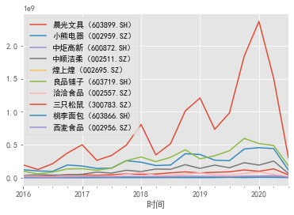

```python
for name in Online_Quarter.columns:
    pd.to_numeric(Online_Quarter[name]).plot()
plt.legend()
```

```python
CSMAR_DATA.index
```

```
Index(['2016-01-01', '2016-03-31', '2016-06-30', '2016-09-30', '2016-12-31',
       '2017-01-01', '2017-03-31', '2017-06-30', '2017-09-30', '2017-12-31',
       '2018-01-01', '2018-03-31', '2018-06-30', '2018-09-30', '2018-12-31',
       '2019-01-01', '2019-03-31', '2019-06-30', '2019-09-30', '2019-12-31',
       '2020-03-31', '2020-06-30'],
      dtype='object', name='Accper')
```

```python
#these are accumulate data, need process
# df.drop(df.index[[1,3]])
CSMAR_DATA = CSMAR_DATA.drop(CSMAR_DATA.index[[0, 5, 10, 15]])
```

```python
CSMAR_DATA
```

| Stkcd Accper | 002511 | 002557 | 002695 | 002956 | 002959 | 300783 | 600872 | 603719 | 603866 | 603899 |
| --- | --- | --- | --- | --- | --- | --- | --- | --- | --- | --- |
| 2016-03-31 | 854090752.85 | 860855341.43 | 297062935.96 | NaN | NaN | NaN | 744203573.06 | NaN | 662040344.40 | 1133433054.53 |
| 2016-06-30 | 1771552660.77 | 1655847883.34 | 662636681.73 | NaN | NaN | NaN | 1490269461.06 | NaN | 1459698895.48 | 2179551131.29 |
| 2016-09-30 | 2740959078.00 | 2532158022.17 | 950361838.24 | NaN | NaN | NaN | 2296102937.77 | NaN | 2377194300.59 | 3452350475.53 |
| 2016-12-31 | 3809349072.13 | 3513011838.49 | 1217821558.54 | NaN | NaN | NaN | 3157988862.51 | NaN | 3305480010.00 | 4662465783.91 |
| 2017-03-31 | 1032246698.85 | 799497081.98 | 336220837.30 | NaN | NaN | NaN | 974197026.86 | NaN | 820164696.08 | 1412887390.59 |
| 2017-06-30 | 2123216428.96 | 1600144160.31 | 757522258.56 | NaN | NaN | NaN | 1804226822.82 | NaN | 1815759674.48 | 2785408071.06 |
| 2017-09-30 | 3352133786.61 | 2509962785.95 | 1132863657.17 | NaN | NaN | NaN | 2728665535.90 | NaN | 2955324232.73 | 4492999748.30 |
| 2017-12-31 | 4638349590.23 | 3602738165.48 | 1477780160.44 | NaN | NaN | NaN | 3609371700.99 | NaN | 4079709861.92 | 6357102964.25 |
| 2018-03-31 | 1224790878.97 | 1026891081.61 | 414858723.95 | NaN | NaN | NaN | 1153599668.70 | NaN | 988899071.86 | 1840309548.13 |
| 2018-06-30 | 2586062097.15 | 1874429650.26 | 1032781229.77 | NaN | NaN | NaN | 2174000422.59 | NaN | 2166657075.00 | 3786631947.71 |
| 2018-09-30 | 4080983764.87 | 2909624990.12 | 1455072897.90 | NaN | NaN | NaN | 3164505966.99 | NaN | 3524423220.31 | 6123592570.19 |
| 2018-12-31 | 5678517623.29 | 4197045559.14 | 1897578656.46 | NaN | NaN | NaN | 4166464950.31 | NaN | 4833227645.58 | 8534988597.55 |
| 2019-03-31 | 1540517206.36 | 1039852311.99 | 499315913.40 | NaN | NaN | NaN | 1231103067.39 | NaN | 1142347222.47 | 2355613820.98 |
| 2019-06-30 | 3172389026.96 | 1987228161.74 | 1168620541.03 | 445047531.11 | NaN | 4511407875.01 | 2392154186.39 | NaN | 2557900566.94 | 4838623016.89 |
| 2019-09-30 | 4819879798.90 | 3219175234.92 | 1677464717.94 | 687410746.86 | 1720792176.02 | 6714643314.62 | 3530582085.17 | NaN | 4121747833.02 | 7947344462.67 |
| 2019-12-31 | 6634914352.68 | 4837252294.43 | 2116915652.97 | 972778161.05 | 2687963985.41 | 10173017103.20 | 4674844437.35 | 7714992860.91 | 5643709759.53 | 11141101364.44 |
| 2020-03-31 | 1670909073.75 | 1146880534.79 | 540658855.66 | 189582824.36 | 739588278.04 | 3412415939.46 | 1153354570.47 | 1908931177.93 | 1322683426.00 | 2083587295.14 |
| 2020-06-30 | 3616201399.80 | 2294482909.95 | 1364636086.06 | 435812860.32 | 1717429151.57 | 5252014479.38 | 2554392490.86 | 3610310717.20 | 2738880462.33 | 4761423672.29 |

[figure not shown]

```python
for name in CSMAR_DATA.columns:
    pd.to_numeric(CSMAR_DATA[name]).plot()
plt.legend()
```